# German_Agrimonia_Case_Study

2. Exploratory Data Analysis (EDA): • Conducting exploratory data analysis to understand the distribution and relationships among variables.

2.1) Summary Statistics

```r
summary(data_german_agrimonia)
```

```
##    IDStations        Latitude       Longitude            Time
##  DEBB063:  2192   Min.   :51.29   Min.   : 7.207   01-01-16:    90
##  DEHE013:  2192   1st Qu.:52.02   1st Qu.: 8.711   01-01-18:    90
##  DEHE024:  2192   Median :53.00   Median : 9.844   01-01-19:    90
##  DEHE049:  2192   Mean   :52.78   Mean   : 9.597   01-02-16:    90
##  DEHE050:  2192   3rd Qu.:53.54   3rd Qu.:10.238   01-02-18:    90
##  DENI011:  2192   Max.   :53.92   Max.   :11.738   01-02-19:    90
##  (Other):181571                                    (Other) :194183
##     Altitude           AQ_pm10           AQ_pm25             AQ_co
##  Min.   :  -1.213   Min.   : -1.016   Min.   : -0.6227   Min.   :-0.0025
##  1st Qu.:   7.066   1st Qu.:  9.483   1st Qu.:  5.3043   1st Qu.: 0.1767
##  Median :  32.569   Median : 13.594   Median :  8.3054   Median : 0.2392
##  Mean   :  94.059   Mean   : 15.770   Mean   : 10.5786   Mean   : 0.2609
##  3rd Qu.: 106.410   3rd Qu.: 19.456   3rd Qu.: 13.3445   3rd Qu.: 0.3219
##  Max.   :1124.760   Max.   :205.194   Max.   :113.4483   Max.   : 1.5405
##
##      AQ_nox             AQ_so2          WE_temp_2m      WE_wind_speed_10m_mean
##  Min.   : -0.4249   Min.   :-1.5010   Min.   :-14.624   Min.   : 0.3702
##  1st Qu.: 11.2938   1st Qu.: 0.8529   1st Qu.:  4.902   1st Qu.: 2.1442
##  Median : 23.0188   Median : 2.0321   Median :  9.987   Median : 2.8484
##  Mean   : 38.4119   Mean   : 2.6067   Mean   : 10.359   Mean   : 3.0697
##  3rd Qu.: 47.2879   3rd Qu.: 2.9681   3rd Qu.: 16.203   3rd Qu.: 3.7530
##  Max.   :701.5600   Max.   :74.4409   Max.   : 30.103   Max.   :13.0289
##
##  WE_tot_precipitation WE_solar_radiation EM_nh3_livestock_mm EM_nh3_agr_soils
##  Min.   :0.000000     Min.   :  181522   Min.   : 0.06688    Min.   : 0.0000
##  1st Qu.:0.001028     1st Qu.: 2800358   1st Qu.: 0.74260    1st Qu.: 0.2925
##  Median :0.008470     Median : 7884699   Median : 1.56001    Median : 1.5433
##  Mean   :0.026554     Mean   : 8920761   Mean   : 2.08856    Mean   : 2.9641
##  3rd Qu.:0.032520     3rd Qu.:14374852   3rd Qu.: 2.70960    3rd Qu.: 3.4817
##  Max.   :0.763869     Max.   :26096335   Max.   :16.58946    Max.   :30.5933
##
##  EM_nh3_agr_waste_burn EM_nox_traffic      LI_bovine        LA_land_use
##  Min.   :0.0000000     Min.   :0.01095   Min.   :  2.612   Min.   :111.0
##  1st Qu.:0.0003108     1st Qu.:0.05326   1st Qu.:  5.035   1st Qu.:112.0
##  Median :0.0029580     Median :0.11288   Median : 15.584   Median :112.0
##  Mean   :0.0118367     Mean   :0.12152   Mean   : 27.468   Mean   :120.6
##  3rd Qu.:0.0118402     3rd Qu.:0.17742   3rd Qu.: 22.822   3rd Qu.:124.0
##  Max.   :0.1692096     Max.   :0.31070   Max.   :139.030   Max.   :142.0
##
```

2.2) Data Visualization to detect Outliers

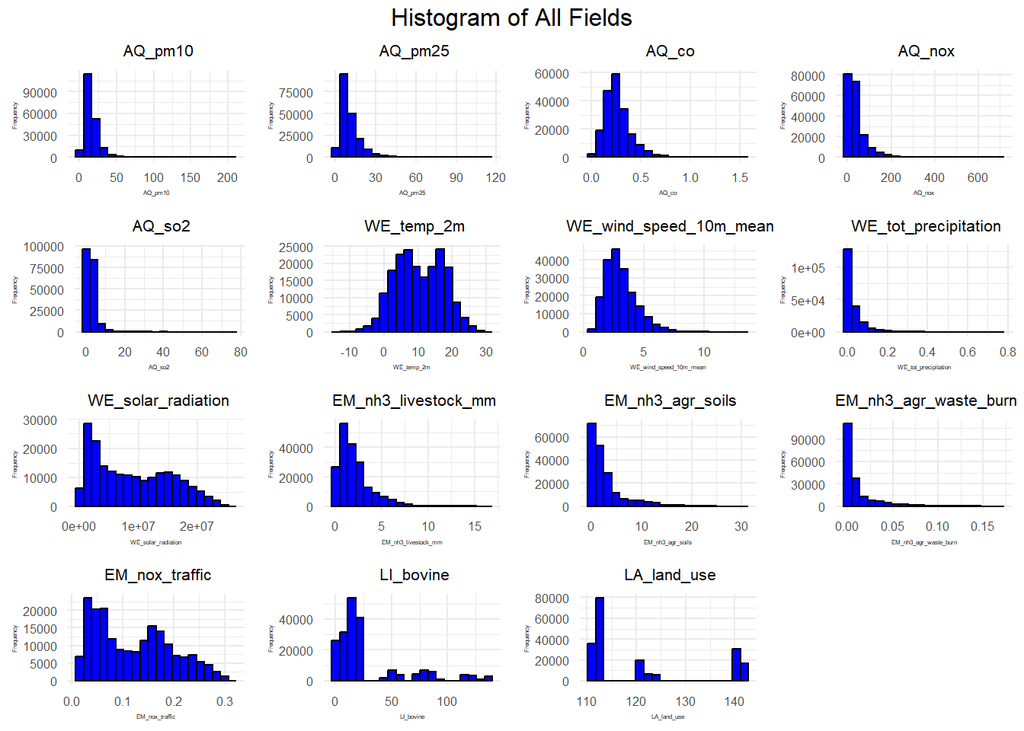

```r
# List of numerical variables
num_vars <- c("AQ_pm10", "AQ_pm25", "AQ_co", "AQ_nox", "AQ_so2", "WE_temp_2m", "WE_wind_speed_10m_mean", "WE_tot_precipitation", "WE_solar_radiation", "EM_nh3_livestock_mm", "EM_nh3_agr_soils", "EM_nh3_agr_waste_burn", "EM_nox_traffic", "LI_bovine", "LA_land_use")

# Create a list to store ggplot objects
plots <- list()
summaries <- list()

# Generate histograms and store them in the list
for (var in num_vars) {
  p <- ggplot(data_german_agrimonia, aes_string(x = var)) +
    geom_histogram(bins = 20, fill = "blue", color = "black") +
    theme_minimal() +
    ggtitle(paste("", var)) +
    xlab(var) +
    ylab("Frequency") +
    theme(plot.title = element_text(hjust = 0.5, size = 8),
          axis.text = element_text(size = 6),
          axis.title = element_text(size = 3))

  plots[[var]] <- p
  # Calculate summary statistics
  summary_stats <- summary(data_german_agrimonia[[var]])
  summaries[[var]] <- summary_stats
}
# Arrange plots in a grid with 2 columns
grid.arrange(grobs = plots, ncol = 4, top = "Histogram of All Fields")
```

```r
# Print summary statistics
for (var in num_vars) {
  cat(paste("Summary statistics for", var, ":\n"))
  print(summaries[[var]])
  cat("\n")
}
```

```
## Summary statistics for AQ_pm10 :
##    Min. 1st Qu.  Median    Mean 3rd Qu.    Max.
##  -1.016   9.483  13.594  15.770  19.456 205.194
##
## Summary statistics for AQ_pm25 :
##     Min.  1st Qu.   Median     Mean  3rd Qu.     Max.
##  -0.6227   5.3043   8.3054  10.5786  13.3445 113.4483
##
## Summary statistics for AQ_co :
##    Min. 1st Qu.  Median    Mean 3rd Qu.    Max.
## -0.0025  0.1767  0.2392  0.2609  0.3219  1.5405
##
## Summary statistics for AQ_nox :
##     Min.  1st Qu.   Median     Mean  3rd Qu.     Max.
##  -0.4249  11.2938  23.0188  38.4119  47.2879 701.5600
##
## Summary statistics for AQ_so2 :
##    Min. 1st Qu.  Median    Mean 3rd Qu.    Max.
## -1.5010  0.8529  2.0321  2.6067  2.9681 74.4409
##
## Summary statistics for WE_temp_2m :
##    Min. 1st Qu.  Median    Mean 3rd Qu.    Max.
## -14.624   4.902   9.987  10.359  16.203  30.103
##
## Summary statistics for WE_wind_speed_10m_mean :
##    Min. 1st Qu.  Median    Mean 3rd Qu.    Max.
##  0.3702  2.1442  2.8484  3.0697  3.7530 13.0289
##
## Summary statistics for WE_tot_precipitation :
##     Min.  1st Qu.   Median     Mean  3rd Qu.     Max.
## 0.000000 0.001028 0.008470 0.026554 0.032520 0.763869
##
## Summary statistics for WE_solar_radiation :
##     Min.  1st Qu.   Median     Mean  3rd Qu.     Max.
##   181522  2800358  7884699  8920761 14374852 26096335
##
## Summary statistics for EM_nh3_livestock_mm :
##     Min.  1st Qu.   Median     Mean  3rd Qu.     Max.
##  0.06688  0.74260  1.56001  2.08856  2.70960 16.58946
##
## Summary statistics for EM_nh3_agr_soils :
##    Min. 1st Qu.  Median    Mean 3rd Qu.    Max.
##  0.0000  0.2925  1.5433  2.9641  3.4817 30.5933
##
## Summary statistics for EM_nh3_agr_waste_burn :
##      Min.   1st Qu.    Median      Mean   3rd Qu.      Max.
## 0.0000000 0.0003108 0.0029580 0.0118367 0.0118402 0.1692096
##
## Summary statistics for EM_nox_traffic :
##    Min. 1st Qu.  Median    Mean 3rd Qu.    Max.
## 0.01095 0.05326 0.11288 0.12152 0.17742 0.31070
##
## Summary statistics for LI_bovine :
##    Min. 1st Qu.  Median    Mean 3rd Qu.    Max.
##   2.612   5.035  15.584  27.468  22.822 139.030
##
## Summary statistics for LA_land_use :
##    Min. 1st Qu.  Median    Mean 3rd Qu.    Max.
##   111.0   112.0   112.0   120.6   124.0   142.0
```

```r
numeric_columns <- c("Latitude", "Longitude", "Altitude", "AQ_pm10", "AQ_pm25", "AQ_co",
                     "AQ_nox", "AQ_so2", "WE_temp_2m", "WE_wind_speed_10m_mean",
                     "WE_tot_precipitation", "WE_solar_radiation", "EM_nh3_livestock_mm",
                     "EM_nh3_agr_soils", "EM_nh3_agr_waste_burn", "EM_nox_traffic",
                     "LI_bovine", "LA_land_use")


data_german_agrimonia[numeric_columns] <- lapply(data_german_agrimonia[numeric_columns], as.numeric)



detect_outliers_modified_zscore <- function(data_german_agrimonia, threshold = 3.5) {
  median_val <- median(data_german_agrimonia, na.rm = TRUE)
  mad_val <- mad(data_german_agrimonia, constant = 1, na.rm = TRUE)
  modified_z_scores <- 0.6745 * (data_german_agrimonia - median_val) / mad_val
  outliers <- abs(modified_z_scores) > threshold
  return(outliers)
}

remove_outliers_modified_zscore <- function(data_german_agrimonia, columns, threshold = 3.5) {
  for (col in columns) {
    outliers <- detect_outliers_modified_zscore(data_german_agrimonia[[col]], threshold)
    data_german_agrimonia <- data_german_agrimonia[!outliers, ]
  }
  return(data_german_agrimonia)
}

data_clean_modified_zscore <- remove_outliers_modified_zscore(data_german_agrimonia, numeric_columns)

summary(data_clean_modified_zscore)
```

```
##           IDStations       Latitude       Longitude            Time
##  STA.DE_DEHB001: 1471   Min.   :51.31   Min.   : 7.614   08-03-20:   43
##  STA.DE_DEHH047: 1414   1st Qu.:52.02   1st Qu.: 8.695   09-08-20:   42
##  STA.DE_DEHH074: 1359   Median :53.00   Median : 9.786   21-05-20:   41
##  STA.DE_DEHH050: 1344   Mean   :52.73   Mean   : 9.540   27-02-20:   41
##  STA.DE_DEHH049: 1300   3rd Qu.:53.54   3rd Qu.:10.111   29-05-20:   41
##  DENI052       : 1260   Max.   :53.90   Max.   :11.738   30-05-19:   41
##  (Other)       :32305                                    (Other) :40204
##     Altitude          AQ_pm10           AQ_pm25            AQ_co
##  Min.   : -1.213   Min.   :-0.5898   Min.   :-0.6227   Min.   :-0.0025
##  1st Qu.: 14.633   1st Qu.: 9.7677   1st Qu.: 5.2447   1st Qu.: 0.1758
##  Median : 39.917   Median :13.6508   Median : 8.0363   Median : 0.2362
##  Mean   : 65.519   Mean   :14.9214   Mean   : 9.3893   Mean   : 0.2476
##  3rd Qu.:106.410   3rd Qu.:18.9153   3rd Qu.:12.4220   3rd Qu.: 0.3079
##  Max.   :189.446   Max.   :38.6597   Max.   :26.4655   Max.   : 0.6019
##
##      AQ_nox            AQ_so2          WE_temp_2m      WE_wind_speed_10m_mean
##  Min.   :-0.2893   Min.   :-1.5010   Min.   :-13.527   Min.   :0.3702
##  1st Qu.:11.8329   1st Qu.: 0.7989   1st Qu.:  4.369   1st Qu.:2.1130
##  Median :22.9208   Median : 1.6329   Median : 10.851   Median :2.7685
##  Mean   :30.3519   Mean   : 2.0316   Mean   : 10.860   Mean   :2.9349
##  3rd Qu.:42.9783   3rd Qu.: 2.6363   3rd Qu.: 17.446   3rd Qu.:3.5837
##  Max.   :99.4327   Max.   : 7.6342   Max.   : 29.867   Max.   :7.0150
##
##  WE_tot_precipitation WE_solar_radiation EM_nh3_livestock_mm EM_nh3_agr_soils
##  Min.   :0.0000000    Min.   :  192513   Min.   :0.06725     Min.   :0.0000
##  1st Qu.:0.0007872    1st Qu.: 3205741   1st Qu.:0.85545     1st Qu.:0.2244
##  Median :0.0058233    Median : 9638190   Median :1.62039     Median :1.4951
##  Mean   :0.0116867    Mean   :10034402   Mean   :1.90795     Mean   :2.2127
##  3rd Qu.:0.0181906    3rd Qu.:15864540   3rd Qu.:2.56303     3rd Qu.:3.3504
##  Max.   :0.0541291    Max.   :24823102   Max.   :6.76896     Max.   :9.2622
##
##  EM_nh3_agr_waste_burn EM_nox_traffic      LI_bovine       LA_land_use
##  Min.   :0.0000000     Min.   :0.01272   Min.   : 2.612   Min.   :111.0
##  1st Qu.:0.0000844     1st Qu.:0.06773   1st Qu.: 4.830   1st Qu.:111.0
##  Median :0.0012937     Median :0.14546   Median :13.485   Median :112.0
##  Mean   :0.0032457     Mean   :0.13662   Mean   :14.155   Mean   :111.7
##  3rd Qu.:0.0051625     3rd Qu.:0.18807   3rd Qu.:18.763   3rd Qu.:112.0
##  Max.   :0.0177236     Max.   :0.30999   Max.   :49.829   Max.   :112.0
##
```

```r
data_german_agrimonia_cleaned <- data_clean_modified_zscore
```

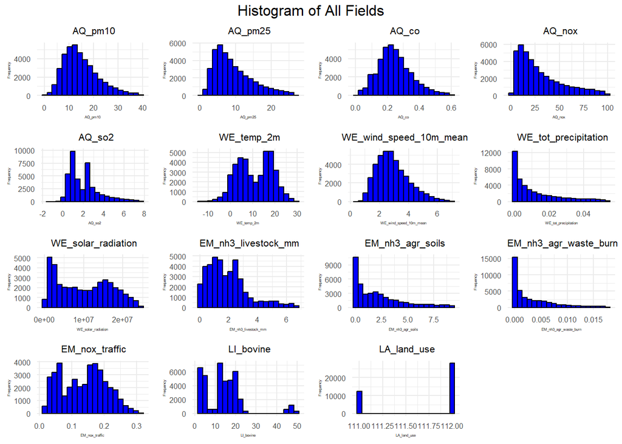

```r
# List of numerical variables
num_vars <- c("AQ_pm10", "AQ_pm25", "AQ_co", "AQ_nox", "AQ_so2", "WE_temp_2m", "WE_wind_speed_10m_mean", "WE_tot_precipitation", "WE_solar_radiation", "EM_nh3_livestock_mm", "EM_nh3_agr_soils", "EM_nh3_agr_waste_burn", "EM_nox_traffic", "LI_bovine", "LA_land_use")

# Create a list to store ggplot objects
plots <- list()
summaries <- list()

# Generate histograms and store them in the list
for (var in num_vars) {
  p <- ggplot(data_german_agrimonia_cleaned, aes_string(x = var)) +
    geom_histogram(bins = 20, fill = "blue", color = "black") +
    theme_minimal() +
    ggtitle(paste("", var)) +
    xlab(var) +
    ylab("Frequency") +
    theme(plot.title = element_text(hjust = 0.5, size = 8),
          axis.text = element_text(size = 6),
          axis.title = element_text(size = 3))

  plots[[var]] <- p
  # Calculate summary statistics
  summary_stats <- summary(data_german_agrimonia_cleaned[[var]])
  summaries[[var]] <- summary_stats
}

# Arrange plots in a grid with 2 columns
grid.arrange(grobs = plots, ncol = 4, top = "Histogram of All Fields")
```

```r
# Print summary statistics for cleaned data and without outliers
for (var in num_vars) {
  cat(paste("Summary statistics for", var, ":\n"))
  print(summaries[[var]])
  cat("\n")
}
```

```
## Summary statistics for AQ_pm10 :
##    Min. 1st Qu.  Median    Mean 3rd Qu.    Max.
## -0.5898  9.7677 13.6508 14.9214 18.9153 38.6597
##
## Summary statistics for AQ_pm25 :
##    Min. 1st Qu.  Median    Mean 3rd Qu.    Max.
## -0.6227  5.2447  8.0363  9.3893 12.4220 26.4655
##
## Summary statistics for AQ_co :
##    Min. 1st Qu.  Median    Mean 3rd Qu.    Max.
## -0.0025  0.1758  0.2362  0.2476  0.3079  0.6019
##
## Summary statistics for AQ_nox :
##    Min. 1st Qu.  Median    Mean 3rd Qu.    Max.
## -0.2893 11.8329 22.9208 30.3519 42.9783 99.4327
##
## Summary statistics for AQ_so2 :
##    Min. 1st Qu.  Median    Mean 3rd Qu.    Max.
## -1.5010  0.7989  1.6329  2.0316  2.6363  7.6342
##
## Summary statistics for WE_temp_2m :
##    Min. 1st Qu.  Median    Mean 3rd Qu.    Max.
## -13.527   4.369  10.851  10.860  17.446  29.867
##
## Summary statistics for WE_wind_speed_10m_mean :
##    Min. 1st Qu.  Median    Mean 3rd Qu.    Max.
##  0.3702  2.1130  2.7685  2.9349  3.5837  7.0150
##
## Summary statistics for WE_tot_precipitation :
##      Min.   1st Qu.    Median      Mean   3rd Qu.      Max.
## 0.0000000 0.0007872 0.0058233 0.0116867 0.0181906 0.0541291
##
## Summary statistics for WE_solar_radiation :
##     Min.  1st Qu.   Median     Mean  3rd Qu.     Max.
##   192513  3205741  9638190 10034402 15864540 24823102
##
## Summary statistics for EM_nh3_livestock_mm :
##    Min. 1st Qu.  Median    Mean 3rd Qu.    Max.
## 0.06725 0.85545 1.62039 1.90795 2.56303 6.76896
##
## Summary statistics for EM_nh3_agr_soils :
##    Min. 1st Qu.  Median    Mean 3rd Qu.    Max.
##  0.0000  0.2244  1.4951  2.2127  3.3504  9.2622
##
## Summary statistics for EM_nh3_agr_waste_burn :
##      Min.   1st Qu.    Median      Mean   3rd Qu.      Max.
## 0.0000000 0.0000844 0.0012937 0.0032457 0.0051625 0.0177236
##
## Summary statistics for EM_nox_traffic :
##    Min. 1st Qu.  Median    Mean 3rd Qu.    Max.
## 0.01272 0.06773 0.14546 0.13662 0.18807 0.30999
##
## Summary statistics for LI_bovine :
##    Min. 1st Qu.  Median    Mean 3rd Qu.    Max.
##   2.612   4.830  13.485  14.155  18.763  49.829
##
## Summary statistics for LA_land_use :
##    Min. 1st Qu.  Median    Mean 3rd Qu.    Max.
##   111.0   111.0   112.0   111.7   112.0   112.0
```

• Outlier Removal Impact: Outlier removal has generally reduced the range and variability of most variables, leading to more consistent and reliable data. • Skewed Distributions: Several variables (e.g., AQ_pm10, AQ_pm25, AQ_so2) remain right-skewed, indicating the presence of high values despite outlier removal. • Symmetry: Variables like AQ_co and some weather metrics have distributions that appear more symmetrical post-cleaning. • Controlled Emissions: Emission-related variables now show a more controlled distribution, reflecting a more realistic range of emissions.

```r
unique_station_ids <- unique(data_german_agrimonia_cleaned$IDStations)
print(unique_station_ids)
```

```
##  [1] DEBB063        DEHE013        DEHE049        DEHH074        DENI020
##  [6] DENI028        DENI031        DENI038        DENI052        DENI054
## [11] DENI066        DENI067        DENI068        DENI075        DENI157
## [16] DENW383        DESH058        DEUB005        STA.DE_DEBB063 STA.DE_DEHB001
## [21] STA.DE_DEHB006 STA.DE_DEHB010 STA.DE_DEHB011 STA.DE_DEHB012 STA.DE_DEHB013
## [26] STA.DE_DEHH015 STA.DE_DEHH026 STA.DE_DEHH047 STA.DE_DEHH049 STA.DE_DEHH050
## [31] STA.DE_DEHH064 STA.DE_DEHH068 STA.DE_DEHH070 STA.DE_DEHH074 STA.DE_DEHH079
## [36] STA.DE_DENW067 STA.DE_DENW200 STA.DE_DENW222 STA.DE_DENW228 STA.DE_DENW260
## [41] STA.DE_DENW268 STA.DE_DENW269 STA.DE_DENW361 STA.DE_DENW383 STA.DE_DESH030
## [46] STA.DE_DESH035 STA.DE_DESH058 STA.DE_DESH059 STA.DE_DEST101 STA.DE_DETH018
## [51] STA.DE_DETH131
## 93 Levels: DEBB063 DEHE013 DEHE024 DEHE049 DEHE050 DEHH033 DEHH072 ... STA.DE_DETH131
```

```r
data_german_agrimonia_cleaned$IDStations <- trimws(data_german_agrimonia_cleaned$IDStations)
unique_station_ids <- unique(data_german_agrimonia_cleaned$IDStations)
print(unique_station_ids)
```

```
##  [1] "DEBB063"        "DEHE013"        "DEHE049"        "DEHH074"
##  [5] "DENI020"        "DENI028"        "DENI031"        "DENI038"
##  [9] "DENI052"        "DENI054"        "DENI066"        "DENI067"
## [13] "DENI068"        "DENI075"        "DENI157"        "DENW383"
## [17] "DESH058"        "DEUB005"        "STA.DE_DEBB063" "STA.DE_DEHB001"
## [21] "STA.DE_DEHB006" "STA.DE_DEHB010" "STA.DE_DEHB011" "STA.DE_DEHB012"
## [25] "STA.DE_DEHB013" "STA.DE_DEHH015" "STA.DE_DEHH026" "STA.DE_DEHH047"
## [29] "STA.DE_DEHH049" "STA.DE_DEHH050" "STA.DE_DEHH064" "STA.DE_DEHH068"
## [33] "STA.DE_DEHH070" "STA.DE_DEHH074" "STA.DE_DEHH079" "STA.DE_DENW067"
## [37] "STA.DE_DENW200" "STA.DE_DENW222" "STA.DE_DENW228" "STA.DE_DENW260"
## [41] "STA.DE_DENW268" "STA.DE_DENW269" "STA.DE_DENW361" "STA.DE_DENW383"
## [45] "STA.DE_DESH030" "STA.DE_DESH035" "STA.DE_DESH058" "STA.DE_DESH059"
## [49] "STA.DE_DEST101" "STA.DE_DETH018" "STA.DE_DETH131"
```

```r
data_german_agrimonia_cleaned$IDStations <- as.character(data_german_agrimonia_cleaned$IDStations)
str(data_german_agrimonia_cleaned$IDStations)
```

```
##  chr [1:40453] "DEBB063" "DEBB063" "DEBB063" "DEBB063" "DEBB063" "DEBB063" ...
```

```r
# Normalize station IDs by removing the "STA.DE_" prefix if it exists
data_german_agrimonia_cleaned$IDStations <- gsub("^STA.DE_", "", data_german_agrimonia_cleaned$IDStations)

# Verify unique station IDs after normalization
unique_station_ids <- unique(data_german_agrimonia_cleaned$IDStations)
print(unique_station_ids)
```

```
##  [1] "DEBB063" "DEHE013" "DEHE049" "DEHH074" "DENI020" "DENI028" "DENI031"
##  [8] "DENI038" "DENI052" "DENI054" "DENI066" "DENI067" "DENI068" "DENI075"
## [15] "DENI157" "DENW383" "DESH058" "DEUB005" "DEHB001" "DEHB006" "DEHB010"
## [22] "DEHB011" "DEHB012" "DEHB013" "DEHH015" "DEHH026" "DEHH047" "DEHH049"
## [29] "DEHH050" "DEHH064" "DEHH068" "DEHH070" "DEHH079" "DENW067" "DENW200"
## [36] "DENW222" "DENW228" "DENW260" "DENW268" "DENW269" "DENW361" "DESH030"
## [43] "DESH035" "DESH059" "DEST101" "DETH018" "DETH131"
```

```r
# Choose two different station IDs for subsetting
station_id1 <- "DEBB063"
station_id2 <- "DENI067"  # Pick another unique ID

# Create subsets for the specified station IDs
station_data1 <- subset(data_german_agrimonia_cleaned, IDStations == station_id1)
station_data2 <- subset(data_german_agrimonia_cleaned, IDStations == station_id2)

# Check the number of observations
cat("Number of observations for station", station_id1, ":", nrow(station_data1), "\n")
```

```
## Number of observations for station DEBB063 : 1682
```

```r
cat("Number of observations for station", station_id2, ":", nrow(station_data2), "\n")
```

```
## Number of observations for station DENI067 : 847
```

```r
# Verify the structure of the subset data
str(station_data1)
```

```
## 'data.frame':    1682 obs. of  20 variables:
##  $ IDStations            : chr  "DEBB063" "DEBB063" "DEBB063" "DEBB063" ...
##  $ Latitude              : num  53 53 53 53 53 ...
##  $ Longitude             : num  11.7 11.7 11.7 11.7 11.7 ...
##  $ Time                  : Factor w/ 2192 levels "01-01-16","01-01-17",..: 865 1009 1225 1441 2017 799 943 1663 1879 1951 ...
##  $ Altitude              : num  28.4 28.4 28.4 28.4 28.4 ...
##  $ AQ_pm10               : num  8.79 18.25 16.75 17.38 9.93 ...
##  $ AQ_pm25               : num  8.38 17.83 16.17 16.62 8.88 ...
##  $ AQ_co                 : num  0.269 0.284 0.375 0.177 0.239 ...
##  $ AQ_nox                : num  23.37 24.02 75.22 33.71 4.98 ...
##  $ AQ_so2                : num  0.799 1.166 2.135 1.103 0.75 ...
##  $ WE_temp_2m            : num  1.732 0.208 -4.225 -4.547 6.122 ...
##  $ WE_wind_speed_10m_mean: num  2.39 2.07 1.96 1.79 5.2 ...
##  $ WE_tot_precipitation  : num  0.044548 0.019153 0.001275 0.000858 0.005194 ...
##  $ WE_solar_radiation    : num  900373 2139699 2020337 2974457 1119294 ...
##  $ EM_nh3_livestock_mm   : num  1.06 1.07 1.07 1.08 1.11 ...
##  $ EM_nh3_agr_soils      : num  0.0351 0.0335 0.0326 0.0345 0.0606 ...
##  $ EM_nh3_agr_waste_burn : num  0.00371 0.00406 0.00455 0.00499 0.00574 ...
##  $ EM_nox_traffic        : num  0.0284 0.0284 0.0285 0.0286 0.029 ...
##  $ LI_bovine             : num  15.2 13 12.7 13.7 13 ...
##  $ LA_land_use           : num  112 112 112 112 112 112 112 112 112 112 ...
```